# DATA7440: Final Project

Aleksei Luchinsky, Mostafa MR

04/25/2023

# Instruction

Buskirk, DATA 7440

Final Assignment, Spring 2023

- This assignment can be completed in groups of 2 to 3 students and you are encouraged to submit your assignment in groups.
- The assignment is worth 100 points and accounts for 40% of your final grade (taking the place of individual quizzes and a group project).
- Your group should submit only one final assignment and you should plan to use R for your submissions via an Rmarkdown file that generates a pdf document.
- Be sure to include your code chunks as part of the solution.
- The assignment is due via canvas submission Tuesday April 25, 2023 by 2pm.

# Problem 1

## Libraries

```r
rm(list = ls())

suppressPackageStartupMessages(library(glmnet))
suppressPackageStartupMessages(library(RWeka))
suppressPackageStartupMessages(library(pre))
suppressPackageStartupMessages(library(randomForest))
suppressPackageStartupMessages(library(caret))
suppressPackageStartupMessages(library(dplyr))
suppressPackageStartupMessages(library(magrittr))
suppressPackageStartupMessages(library(ggplot2))
suppressPackageStartupMessages(library(iml))

# I need to attach these libraries to suppress messages from Interaction$new
suppressPackageStartupMessages(library(fs))
suppressPackageStartupMessages(library(xml2))
suppressPackageStartupMessages(library(jsonlite))
suppressPackageStartupMessages(library(broom))
suppressPackageStartupMessages(library(dbplyr))
suppressPackageStartupMessages(library(readr))
suppressPackageStartupMessages(library(httr))
suppressPackageStartupMessages(library(gargle))
suppressPackageStartupMessages(library(rvest))
suppressPackageStartupMessages(library(googlesheets4))
suppressPackageStartupMessages(library(hms))
```

## Datset

```r
load("./data/external/apipop1.RData")
str(apipop_train1)
```

```
'data.frame':   4474 obs. of  16 variables:
 $ awards  : Factor w/ 2 levels "No","Yes": 1 2 1 1 1 1 2 2 2 2 ...
 $ stype   : Factor w/ 3 levels "E","H","M": 1 1 2 2 2 2 1 1 1 1 ...
 $ meals   : int  88 70 31 4 37 9 17 21 42 65 ...
 $ ell     : int  13 32 18 3 29 2 3 12 16 48 ...
 $ mobility: int  13 37 13 7 9 6 14 12 16 20 ...
 $ pct.resp: int  83 90 75 90 95 89 89 99 58 57 ...
 $ not.hsg : int  27 21 39 1 41 1 7 10 14 10 ...
 $ hsg     : int  36 37 20 8 19 13 36 35 16 26 ...
 $ some.col: int  30 33 19 19 19 29 25 18 34 27 ...
 $ col.grad: int  4 9 20 44 17 39 27 26 22 25 ...
 $ grad.sch: int  2 1 2 29 4 17 5 11 14 12 ...
 $ avg.ed  : num  2.18 2.32 2.25 3.91 2.25 ...
 $ full    : int  79 79 89 100 91 94 89 100 95 63 ...
 $ emer    : int  14 21 11 4 9 6 11 0 5 37 ...
 $ enroll  : int  275 325 990 2306 2132 1215 262 377 639 509 ...
 $ api.stu : int  216 278 809 2115 1205 1144 226 337 570 435 ...
```

## Functions

```r
fill.table <- function(model_name, pred_func, y_train=apipop_train1$awards, y_test = y.test,
                       trainX = apipop_train1,
                       testX = apipop_test1) {
  train.predictions <- pred_func(trainX)
  cm.train = confusionMatrix(train.predictions, y_train)
  test.predictions <- pred_func(testX)
  cm.test = confusionMatrix(test.predictions, y_test)
  return(data.frame(
    model = model_name,
    test.accuracy = cm.test$overall[1],
    test.kappa = cm.test$overall[2],
    train.accuracy = cm.train$overall[1],
    train.kappa = cm.train$overall[2]
  ))
}
```

## Part 1: Generating the Models

Preparing train data

```r
y.train <- apipop_train1$awards
y.test <- apipop_test1$awards
```

### a) LASSO

> construct a LASSO model that predicts whether or not a school qualified for it’s award program. Use 5-fold cross validation on the apipop_train1 dataset to determine the penalty parameter and specify the seed 7440 prior to running the model.

```r
set.seed(7440)
cv.lasso.model <<- cv.glmnet(
  x = data.matrix(apipop_train1[,-1]),
  y = apipop_train1[,1],
  alpha = 1, standardize = TRUE, nfolds = 5, family = "binomial")
```

The best penalty parameter is

```r
cv.lasso.model$lambda.min
```

```
[1] 0.0005778871
```

```r
lasso.best.lambda <- cv.lasso.model$lambda.min
```

Here is the modal trained with this value of parameter

```r
lasso.best.model <- glmnet(
  x = data.matrix(apipop_train1[,-1]),
  y = apipop_train1[,1],
  alpha = 1, lambda = lasso.best.lambda, family = "binomial")
```

### b) oneR

> Now apply a one rule algorithm to determine the feature that most explains the award outcomes.

```r
oneR.model <- OneR::OneR(awards ~ ., data = apipop_train1)
oneR.model
```

```
Call:
OneR.formula(formula = awards ~ ., data = apipop_train1)

Rules:
If stype = E then awards = Yes
If stype = H then awards = No
If stype = M then awards = Yes

Accuracy:
3143 of 4474 instances classified correctly (70.25%)
```

As you can see, the feature, that is most useful to explain the outcome is **stype**

### c) Sequential Covering

> Now apply a sequential covering algorithm to expand the rule set derived in B.

```r
seq.model <- JRip(awards ~ ., data = apipop_test1)
seq.model
```

```
JRIP rules:
===========

(enroll >= 687) and (stype = H) => awards=No (154.0/48.0)
(grad.sch <= 9) and (enroll >= 1082) => awards=No (42.0/10.0)
(enroll >= 600) and (not.hsg >= 24) and (stype = M) => awards=No (48.0/19.0)
(stype = H) => awards=No (35.0/14.0)
 => awards=Yes (1220.0/314.0)

Number of Rules : 5
```

As you can see, the **stype** variable is part of almost all of the rules, so it is important

### d) Rule-Fit

> Now apply a rule-fit algorithm to determine features and possible interaction effects that are important for explaining award qualification. For this model set the seed to be 2021 and also use 5 folds.

```r
set.seed(2021)
rule.fit.model <- pre(awards ~ .,
                       data = apipop_train1,
                       family = "binomial", nfolds = 5
                       )
```

This model also tells that **stype** is the most important variable:

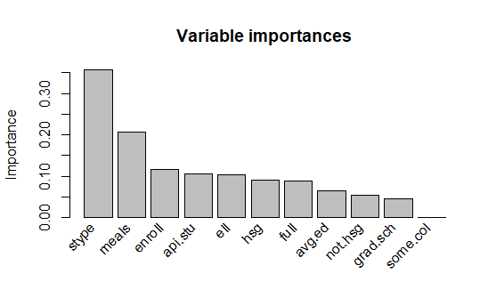

```r
rule.fit.imps <- pre::importance(rule.fit.model)
```

```r
rule.fit.imps$baseimps %>% head(10)
```

[output not shown]

Most important rules here are

## Part 2: Comparing The Models

> Using the respective models create a table that provides overall accuracy, sensitivity and specificity for predicting if a school qualified for its awards program using the apipop_test1 as the test set for each of the models you derived in parts a-d of Part 1.

```r
y.test <- apipop_test1$awards
cm.table <- data.frame()
```

I will use this function to collect statistics about model’s accuracy and kappa on training and test sets

```r
fill.table <- function(model_name, pred_func, y_train=apipop_train1$awards, y_test = y.test,
                       trainX = apipop_train1,
                       testX = apipop_test1) {
  train.predictions <- pred_func(trainX)
  cm.train = confusionMatrix(train.predictions, y_train)
  test.predictions <- pred_func(testX)
  cm.test = confusionMatrix(test.predictions, y_test)
  return(data.frame(
    model = model_name,
    test.accuracy = cm.test$overall[1],
    test.kappa = cm.test$overall[2],
    train.accuracy = cm.train$overall[1],
    train.kappa = cm.train$overall[2]
  ))
}
```

### a) LASSO model

```r
cm.table <- rbind(cm.table,
  fill.table("LASSO",
           pred_func = function(X) {
             probs = predict(lasso.best.model, newx = data.matrix(X), type = "response")
             as.factor(as.vector(ifelse( probs> 0.5, "Yes", "No")))
}, trainX = apipop_train1[,-1], testX = apipop_test1[,-1])
)
```

### b) OneR

```r
cm.table <- rbind(cm.table,
  fill.table("OneR",
           pred_func = function(X) {
             as.factor(predict(oneR.model, X))
})
)
```

### c) Sequential model

```r
cm.table <- rbind(cm.table,
  fill.table("SeqCover",
           pred_func = function(X) {
             as.factor(predict(seq.model, X))
})
)
```

### d) Rule Fit

```r
cm.table <- rbind(cm.table,
  fill.table("RuleFit",
           pred_func = function(X) {
             probs = predict(rule.fit.model, newdata = X, type = "response")
             as.factor(as.vector(ifelse( probs> 0.5, "Yes", "No")))
})
)
```

### e) Results

```r
rownames(cm.table) <- 1:nrow(cm.table)
cm.table %>% mutate_if(is.numeric, round, digits = 3) %>% arrange(test.accuracy)
```

| model | test.accuracy | test.kappa | train.accuracy | train.kappa |
| --- | --- | --- | --- | --- |
| LASSO | 0.705 | 0.217 | 0.700 | 0.173 |
| OneR | 0.708 | 0.226 | 0.703 | 0.188 |
| RuleFit | 0.712 | 0.256 | 0.719 | 0.248 |
| SeqCover | 0.730 | 0.318 | 0.701 | 0.225 |

As you can see, sequential covering is the best model both in terms of test accuracy and test kappa.